# Zadanie Domowe 3

Maciej Janta Lipinski

2023-03-29

# Wstęp i krótki opis badania

W ramach eksperymentu z zadania domowego sprawdziłem jak dobrze ankietowani są w stanie odczytywać dane z różnych typów wykresów. Badanie przeprowadziłem na grupie 23 osób, w różnym wieku i wykształceniu, niemających żadnej styczności z zagadnieniami wizualizacji danych. W tym celu korzystając z ramki danych zawierającej statystyki zawodników z drużyn najlepszej zawodowej koszykarskiej ligi świata tj. NBA. Utworzyłem trzy poniższe wykresy obrazujące ile punktów zdobywały poszczególne drużyny NBA w sezonie regularnym 2019/2020 (chodzi o punkty rzucane w meczach). Pierwsze dwa są różnymi wariancjami wykresu kołowego, a ostatni jest prostym wykresem kolumnowym. Przeprowadziłem ankietę, w której prosiłem o:

1. odczytanie z wykresów ilości punktów dla konkretnej drużyny
2. wskazanie drużyny z najmniejszą oraz największą zdobyczą punktową
3. uszeregowanie drużyn ze względu na liczbę zdobytych punktów

Na koniec jeszcze poprosiłem, aby wskazano wykres, który zdaniem ankietowanych jest najczytelniejszy. (każdy wykres posiadał ten sam zestaw pytań)

# Cel eksperymentu

Sprawdzenie, czy wykres kolumnowy (nawet tak “średnio” wykonany) będzie czytelniejszy i bardziej przejrzysty niż wykresy kołowe.

# Wykresy na których przeprowadzone zostało badanie

### Wykres 1.

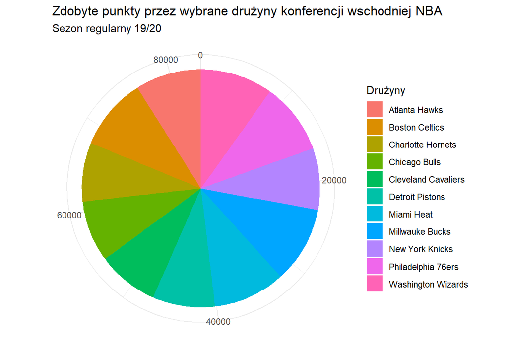

### Wykres 2.

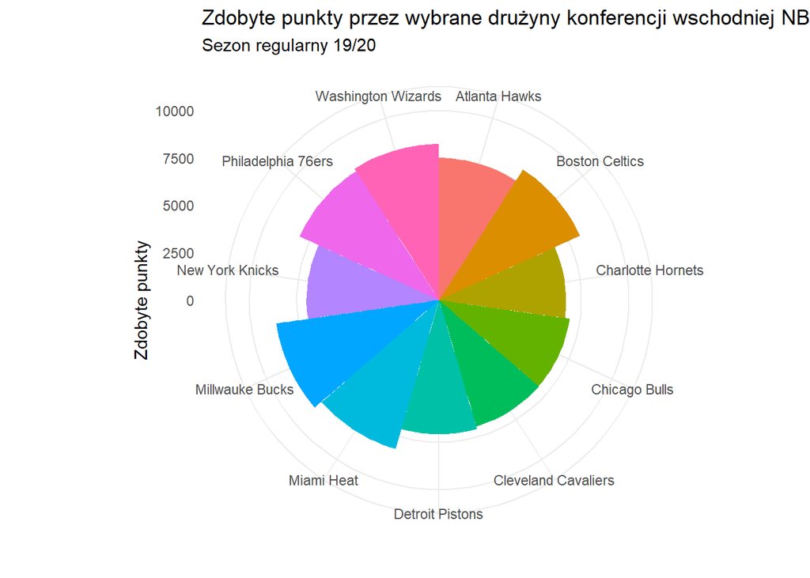

### Wykres 3.

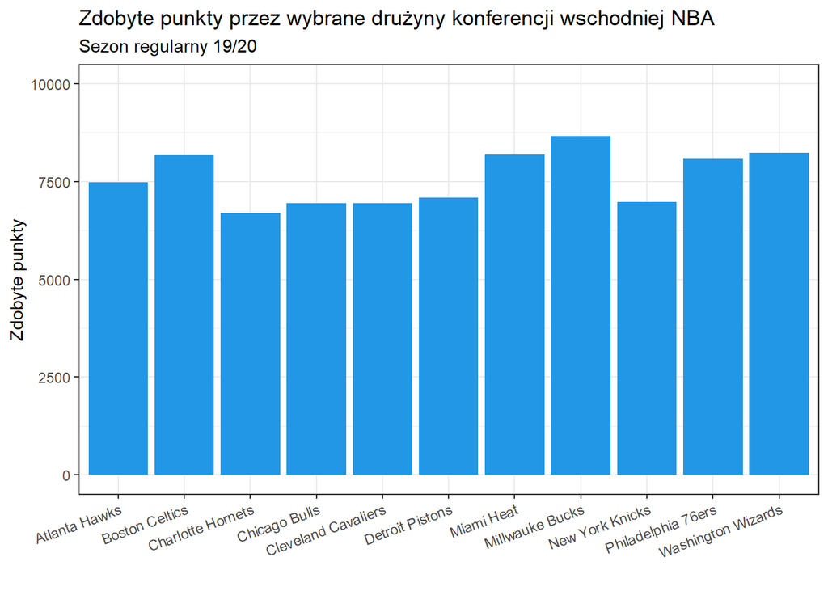

# Przebieg badania

Grupa badawcza miała do wypełnienia ankietę, w której do każdego wykresu zadane zostały 4 pytania.

### Zadanie 1

Zadanie 1 polegało na wybraniu, która z drużyn zdobyła najwięcej punktów w sezonie regularnym. Poprawna odpoweidź: **Milwaukee Bucks**

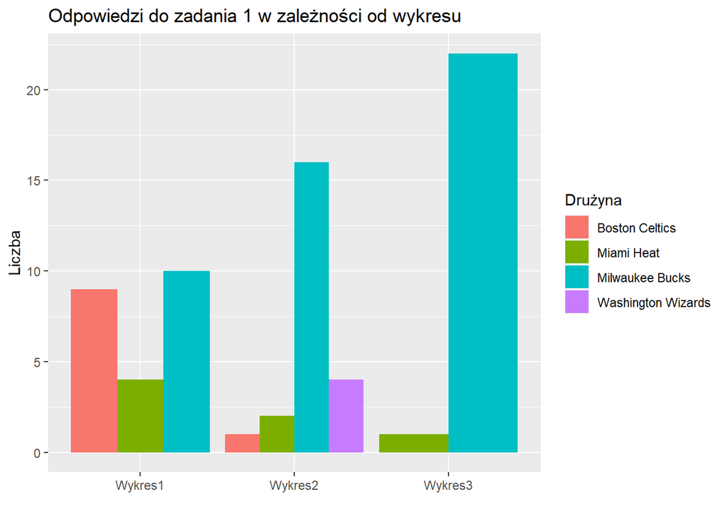

### Zadanie 2

Zadanie 2 (analogicznie do zadania pierwszego) polegało na wybraniu, która z drużyn zdobyła najmniej punktów w sezonie regularnym. Poprawna odpoweidź: **Charlotte Hornets**

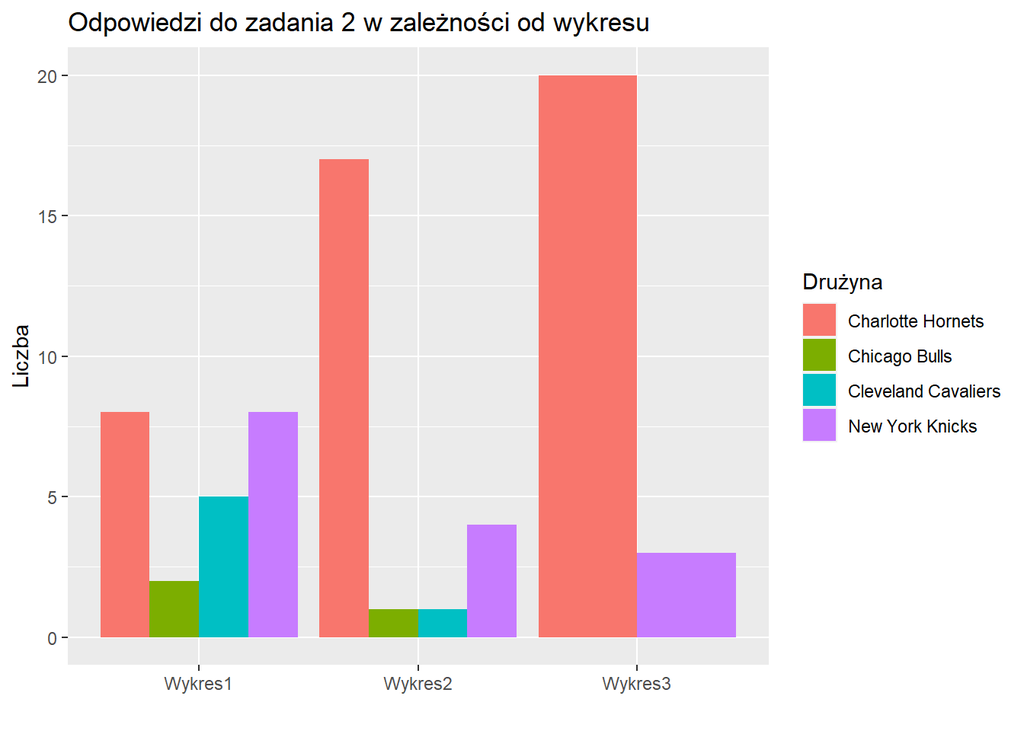

**Obserwacje z zadania pierwszego i drugiego:**

Oba zadania polegały na tym samym i można, także zaobserwować podobne wnioski. Mniej niż połowa respondentów wskazała poprawną odpowiedź na te pytania dla *Wykres1*, łącznie pojawiły się aż 4 odpowiedzi, świadczy to o złudzeniu jaki powoduje wykres kołowy, przez co nie byli, która z danych jest największa/najmniejsza. Dla *Wykres2* już zdecydowana większość była w stanie wskazać, która z drużyn zdobyła najwięcej/najmniej punktów, choć wciąż kilka osób “dawało się nabrać” i odpowiadało błędnie. Odpowiedzi dla *Wykres3* są już jednoznaczne i ankietowani nie mieli problemów z wyborem poprawnej odpowiedzi.

### Zadanie 3

W tym zadaniu poprosiłem ankietowanych o uszeregowanie rosnąco podanych drużyn (czyli Atlanta Hawks, Philadelphia 76ers, Boston Celtics oraz Detroit Pistons)ze względu na liczbe zdobytych punktów.

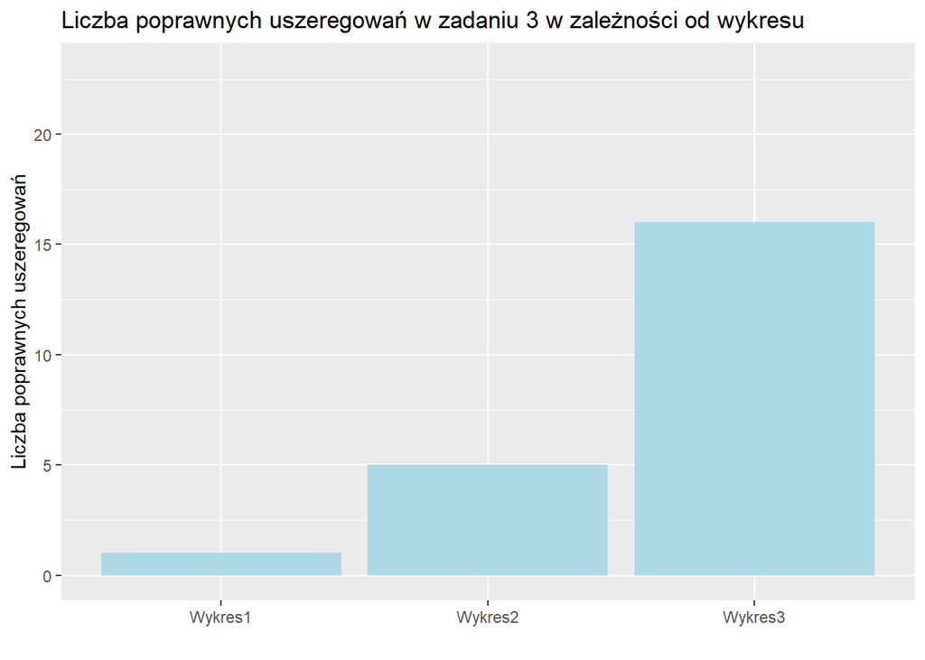

**Obserwacje z zadania trzeciego:**

Pomimo, iż wartości są naprawdę bliskie to i tak odczytując dane z *Wykres3* aż 16 osób poprawnie podało dobrą kolejność drużyn. W przeciwieństwie do *Wykres3* pozostałe wykresy nie były na tyle czytelne, aby spora część ankietowanych nie pomyliła się. Więc otrzymaliśmy bardzo mało poprawnych odpowiedzi (odpowiednio 1 i 5).

### Zadanie 4

To zadanie polegało na odczytaniu z wykresu ilości punktów jaką zdobyła drużyna Milwaukee Bucks (8670, zaznaczone na wykresie czarną linią).

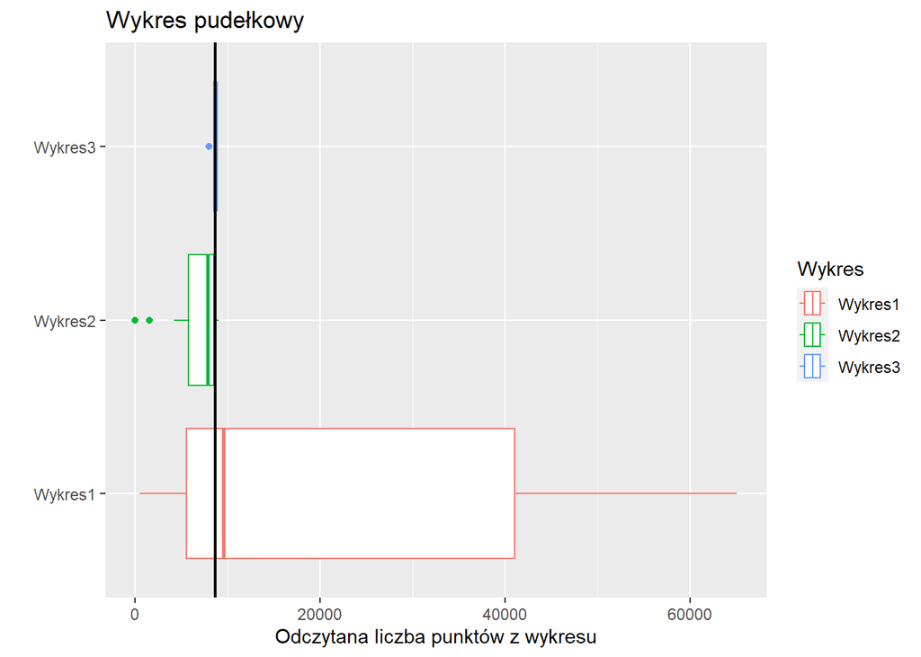

# Wnioski

Z wyników ankiety możemy jednoznacznie wywnioskować, że wykres kolumnowy jest o wiele czytelniejszy niż wykres kołowy, a także że najczęstszymi problemami pojawiającymi się jesli chodzi o wykersy kołowe, to pojawiające się złudzenia, gdy chcemy porównać podobne wartości, tym bardziej kiedy obserwacje nie sąsiadują ze sobą. Problemem jest także z odczytywaniem konkretnych wartości. Na koniec spytałem ankietowanych o odczucia i jednym głosem wskazali, że wykres kolumnowy jest o wiele przyjemniejszy w odbiorze od wykersów kołowych i z nim im się najlepiej pracowało.